# CoViD_in_HH_final_v0.1

John-Philipp Vogt

29/04/2022

# 0 Packages and Scripts

Script runs: Load `tidyverse` and `gridExtra` packages, load `RKI_imptran`, `RKI_geofil`, `df_age_bracket_ref_date`, `df_age_bracket_rep_date` and various other scripts.

```r
library(tidyverse)
library(gridExtra)
RKI_imptran <- function(x){
  read_csv(x, col_types = list(
    Altersgruppe = col_factor(),
    Geschlecht = col_factor(),
    IstErkrankungsbeginn = col_logical()
  )) %>%
    rename(geo_ID = IdLandkreis,age_group = Altersgruppe,
           sex = Geschlecht, rep_date = Meldedatum,
           ref_date = Refdatum, ref_rep_date = IstErkrankungsbeginn,
           amount_case = AnzahlFall, amount_death = AnzahlTodesfall,
           amount_recovery = AnzahlGenesen, new_case = NeuerFall,
           new_death = NeuerTodesfall, new_recovery = NeuGenesen)
}

RKI_geofil <- function(x, y){
  x %>% filter(geo_ID == y)
}

df_age_brackets_ref_date <- function(){
  A0 <- inf_HH %>% select(ref_date, age_group, amount_case) %>%
    arrange(ref_date) %>%
    group_by(ref_date, age_group) %>%
    summarise(amount_case = sum(amount_case)) %>%
    ungroup %>%
    filter(age_group == "unbekannt") %>%
    arrange(ref_date) %>%
    mutate(cum_cases = cumsum(amount_case))

  A1 <- inf_HH %>% select(ref_date, age_group, amount_case) %>%
    arrange(ref_date) %>%
    group_by(ref_date, age_group) %>%
    summarise(amount_case = sum(amount_case)) %>%
    ungroup %>%
    filter(age_group == "A00-A04") %>%
    arrange(ref_date) %>%
    mutate(cum_cases = cumsum(amount_case))

  A2 <- inf_HH %>% select(ref_date, age_group, amount_case) %>%
    arrange(ref_date) %>%
    group_by(ref_date, age_group) %>%
    summarise(amount_case = sum(amount_case)) %>%
    ungroup %>%
    filter(age_group == "A05-A14") %>%
    arrange(ref_date) %>%
    mutate(cum_cases = cumsum(amount_case))

  A3 <- inf_HH %>% select(ref_date, age_group, amount_case) %>%
    arrange(ref_date) %>%
    group_by(ref_date, age_group) %>%
    summarise(amount_case = sum(amount_case)) %>%
    ungroup %>%
    filter(age_group == "A15-A34") %>%
    arrange(ref_date) %>%
    mutate(cum_cases = cumsum(amount_case))

  A4 <- inf_HH %>% select(ref_date, age_group, amount_case) %>%
    arrange(ref_date) %>%
    group_by(ref_date, age_group) %>%
    summarise(amount_case = sum(amount_case)) %>%
    ungroup %>%
    filter(age_group == "A35-A59") %>%
    arrange(ref_date) %>%
    mutate(cum_cases = cumsum(amount_case))

  A5 <- inf_HH %>% select(ref_date, age_group, amount_case) %>%
    arrange(ref_date) %>%
    group_by(ref_date, age_group) %>%
    summarise(amount_case = sum(amount_case)) %>%
    ungroup %>%
    filter(age_group == "A60-A79") %>%
    arrange(ref_date) %>%
    mutate(cum_cases = cumsum(amount_case))

  A6 <- inf_HH %>% select(ref_date, age_group, amount_case) %>%
    arrange(ref_date) %>%
    group_by(ref_date, age_group) %>%
    summarise(amount_case = sum(amount_case)) %>%
    ungroup %>%
    filter(age_group == "A80+") %>%
    arrange(ref_date) %>%
    mutate(cum_cases = cumsum(amount_case))

    rbind(A0, A1, A2, A3, A4, A5, A6)
}

df_age_brackets_rep_date <- function(){
  A0 <- inf_HH %>% select(rep_date, age_group, amount_case) %>%
    arrange(rep_date) %>%
    group_by(rep_date, age_group) %>%
    summarise(amount_case = sum(amount_case)) %>%
    ungroup %>%
    filter(age_group == "unbekannt") %>%
    arrange(rep_date) %>%
    mutate(cum_cases = cumsum(amount_case))

  A1 <- inf_HH %>% select(rep_date, age_group, amount_case) %>%
    arrange(rep_date) %>%
    group_by(rep_date, age_group) %>%
    summarise(amount_case = sum(amount_case)) %>%
    ungroup %>%
    filter(age_group == "A00-A04") %>%
    arrange(rep_date) %>%
    mutate(cum_cases = cumsum(amount_case))

  A2 <- inf_HH %>% select(rep_date, age_group, amount_case) %>%
    arrange(rep_date) %>%
    group_by(rep_date, age_group) %>%
    summarise(amount_case = sum(amount_case)) %>%
    ungroup %>%
    filter(age_group == "A05-A14") %>%
    arrange(rep_date) %>%
    mutate(cum_cases = cumsum(amount_case))

  A3 <- inf_HH %>% select(rep_date, age_group, amount_case) %>%
    arrange(rep_date) %>%
    group_by(rep_date, age_group) %>%
    summarise(amount_case = sum(amount_case)) %>%
    ungroup %>%
    filter(age_group == "A15-A34") %>%
    arrange(rep_date) %>%
    mutate(cum_cases = cumsum(amount_case))

  A4 <- inf_HH %>% select(rep_date, age_group, amount_case) %>%
    arrange(rep_date) %>%
    group_by(rep_date, age_group) %>%
    summarise(amount_case = sum(amount_case)) %>%
    ungroup %>%
    filter(age_group == "A35-A59") %>%
    arrange(rep_date) %>%
    mutate(cum_cases = cumsum(amount_case))

  A5 <- inf_HH %>% select(rep_date, age_group, amount_case) %>%
    arrange(rep_date) %>%
    group_by(rep_date, age_group) %>%
    summarise(amount_case = sum(amount_case)) %>%
    ungroup %>%
    filter(age_group == "A60-A79") %>%
    arrange(rep_date) %>%
    mutate(cum_cases = cumsum(amount_case))

  A6 <- inf_HH %>% select(rep_date, age_group, amount_case) %>%
    arrange(rep_date) %>%
    group_by(rep_date, age_group) %>%
    summarise(amount_case = sum(amount_case)) %>%
    ungroup %>%
    filter(age_group == "A80+") %>%
    arrange(rep_date) %>%
    mutate(cum_cases = cumsum(amount_case))

  rbind(A0, A1, A2, A3, A4, A5, A6)
}

df_sex_ref_date <- function(){

  M <- inf_HH %>% select(ref_date, sex, amount_case) %>%
    arrange(ref_date) %>%
    group_by(ref_date, sex) %>%
    summarise(amount_case = sum(amount_case)) %>%
    ungroup %>%
    filter(sex == "M") %>%
    arrange(ref_date) %>%
    mutate(cum_cases = cumsum(amount_case))

  W <- inf_HH %>% select(ref_date, sex, amount_case) %>%
    arrange(ref_date) %>%
    group_by(ref_date, sex) %>%
    summarise(amount_case = sum(amount_case)) %>%
    ungroup %>%
    filter(sex == "W") %>%
    arrange(ref_date) %>%
    mutate(cum_cases = cumsum(amount_case))

  unbekannt <- inf_HH %>% select(ref_date, sex, amount_case) %>%
    arrange(ref_date) %>%
    group_by(ref_date, sex) %>%
    summarise(amount_case = sum(amount_case)) %>%
    ungroup %>%
    filter(sex == "unbekannt") %>%
    arrange(ref_date) %>%
    mutate(cum_cases = cumsum(amount_case))

  df_sex_ref_date <- rbind(M, W, unbekannt)
}
```

```r
df_sex_rep_date <- function(){

  M <- inf_HH %>% select(rep_date, sex, amount_case) %>%
    arrange(rep_date) %>%
    group_by(rep_date, sex) %>%
    summarise(amount_case = sum(amount_case)) %>%
    ungroup %>%
    filter(sex == "M") %>%
    arrange(rep_date) %>%
    mutate(cum_cases = cumsum(amount_case))

  W <- inf_HH %>% select(rep_date, sex, amount_case) %>%
    arrange(rep_date) %>%
    group_by(rep_date, sex) %>%
    summarise(amount_case = sum(amount_case)) %>%
    ungroup %>%
    filter(sex == "W") %>%
    arrange(rep_date) %>%
    mutate(cum_cases = cumsum(amount_case))

  unbekannt <- inf_HH %>% select(rep_date, sex, amount_case) %>%
    arrange(rep_date) %>%
    group_by(rep_date, sex) %>%
    summarise(amount_case = sum(amount_case)) %>%
    ungroup %>%
    filter(sex == "unbekannt") %>%
    arrange(rep_date) %>%
    mutate(cum_cases = cumsum(amount_case))

  df_sex_rep_date <- rbind(M, W, unbekannt)
}

df_age_brackets_ref_date_deaths <- function(){
  A0 <- inf_HH %>% select(ref_date, age_group, amount_death) %>%
    arrange(ref_date) %>%
    group_by(ref_date, age_group) %>%
    summarise(amount_death = sum(amount_death)) %>%
    ungroup %>%
    filter(age_group == "unbekannt") %>%
    arrange(ref_date) %>%
    mutate(cum_cases = cumsum(amount_death))

  A1 <- inf_HH %>% select(ref_date, age_group, amount_death) %>%
    arrange(ref_date) %>%
    group_by(ref_date, age_group) %>%
    summarise(amount_death = sum(amount_death)) %>%
    ungroup %>%
    filter(age_group == "A00-A04") %>%
    arrange(ref_date) %>%
    mutate(cum_cases = cumsum(amount_death))

  A2 <- inf_HH %>% select(ref_date, age_group, amount_death) %>%
    arrange(ref_date) %>%
    group_by(ref_date, age_group) %>%
    summarise(amount_death = sum(amount_death)) %>%
    ungroup %>%
    filter(age_group == "A05-A14") %>%
    arrange(ref_date) %>%
    mutate(cum_cases = cumsum(amount_death))

  A3 <- inf_HH %>% select(ref_date, age_group, amount_death) %>%
    arrange(ref_date) %>%
    group_by(ref_date, age_group) %>%
    summarise(amount_death = sum(amount_death)) %>%
    ungroup %>%
    filter(age_group == "A15-A34") %>%
    arrange(ref_date) %>%
    mutate(cum_cases = cumsum(amount_death))

  A4 <- inf_HH %>% select(ref_date, age_group, amount_death) %>%
    arrange(ref_date) %>%
    group_by(ref_date, age_group) %>%
    summarise(amount_death = sum(amount_death)) %>%
    ungroup %>%
    filter(age_group == "A35-A59") %>%
    arrange(ref_date) %>%
    mutate(cum_cases = cumsum(amount_death))

  A5 <- inf_HH %>% select(ref_date, age_group, amount_death) %>%
    arrange(ref_date) %>%
    group_by(ref_date, age_group) %>%
    summarise(amount_death = sum(amount_death)) %>%
    ungroup %>%
    filter(age_group == "A60-A79") %>%
    arrange(ref_date) %>%
    mutate(cum_cases = cumsum(amount_death))

  A6 <- inf_HH %>% select(ref_date, age_group, amount_death) %>%
    arrange(ref_date) %>%
    group_by(ref_date, age_group) %>%
    summarise(amount_death = sum(amount_death)) %>%
    ungroup %>%
    filter(age_group == "A80+") %>%
    arrange(ref_date) %>%
    mutate(cum_cases = cumsum(amount_death))

  rbind(A0, A1, A2, A3, A4, A5, A6)
}

df_age_brackets_rep_date_deaths <- function(){
  A0 <- inf_HH %>% select(rep_date, age_group, amount_death) %>%
    arrange(rep_date) %>%
    group_by(rep_date, age_group) %>%
    summarise(amount_death = sum(amount_death)) %>%
    ungroup %>%
    filter(age_group == "unbekannt") %>%
    arrange(rep_date) %>%
    mutate(cum_cases = cumsum(amount_death))

  A1 <- inf_HH %>% select(rep_date, age_group, amount_death) %>%
    arrange(rep_date) %>%
    group_by(rep_date, age_group) %>%
    summarise(amount_death = sum(amount_death)) %>%
    ungroup %>%
    filter(age_group == "A00-A04") %>%
    arrange(rep_date) %>%
    mutate(cum_cases = cumsum(amount_death))

  A2 <- inf_HH %>% select(rep_date, age_group, amount_death) %>%
    arrange(rep_date) %>%
    group_by(rep_date, age_group) %>%
    summarise(amount_death = sum(amount_death)) %>%
    ungroup %>%
    filter(age_group == "A05-A14") %>%
    arrange(rep_date) %>%
    mutate(cum_cases = cumsum(amount_death))

  A3 <- inf_HH %>% select(rep_date, age_group, amount_death) %>%
    arrange(rep_date) %>%
    group_by(rep_date, age_group) %>%
    summarise(amount_death = sum(amount_death)) %>%
    ungroup %>%
    filter(age_group == "A15-A34") %>%
    arrange(rep_date) %>%
    mutate(cum_cases = cumsum(amount_death))

  A4 <- inf_HH %>% select(rep_date, age_group, amount_death) %>%
    arrange(rep_date) %>%
    group_by(rep_date, age_group) %>%
    summarise(amount_death = sum(amount_death)) %>%
    ungroup %>%
    filter(age_group == "A35-A59") %>%
    arrange(rep_date) %>%
    mutate(cum_cases = cumsum(amount_death))

  A5 <- inf_HH %>% select(rep_date, age_group, amount_death) %>%
    arrange(rep_date) %>%
    group_by(rep_date, age_group) %>%
    summarise(amount_death = sum(amount_death)) %>%
    ungroup %>%
    filter(age_group == "A60-A79") %>%
    arrange(rep_date) %>%
    mutate(cum_cases = cumsum(amount_death))

  A6 <- inf_HH %>% select(rep_date, age_group, amount_death) %>%
    arrange(rep_date) %>%
    group_by(rep_date, age_group) %>%
    summarise(amount_death = sum(amount_death)) %>%
    ungroup %>%
    filter(age_group == "A80+") %>%
    arrange(rep_date) %>%
    mutate(cum_cases = cumsum(amount_death))

  rbind(A0, A1, A2, A3, A4, A5, A6)
}

df_sex_ref_date_deaths <- function(){

  M <- inf_HH %>% select(ref_date, sex, amount_death) %>%
    arrange(ref_date) %>%
    group_by(ref_date, sex) %>%
    summarise(amount_death = sum(amount_death)) %>%
    ungroup %>%
    filter(sex == "M") %>%
    arrange(ref_date) %>%
    mutate(cum_cases = cumsum(amount_death))

  W <- inf_HH %>% select(ref_date, sex, amount_death) %>%
    arrange(ref_date) %>%
    group_by(ref_date, sex) %>%
    summarise(amount_death = sum(amount_death)) %>%
    ungroup %>%
    filter(sex == "W") %>%
    arrange(ref_date) %>%
    mutate(cum_cases = cumsum(amount_death))
```

```r
  unbekannt <- inf_HH %>% select(ref_date, sex, amount_death) %>%
    arrange(ref_date) %>%
    group_by(ref_date, sex) %>%
    summarise(amount_death = sum(amount_death)) %>%
    ungroup %>%
    filter(sex == "unbekannt") %>%
    arrange(ref_date) %>%
    mutate(cum_cases = cumsum(amount_death))

    rbind(M, W, unbekannt)
}

df_sex_rep_date_deaths <- function(){

  M <- inf_HH %>% select(rep_date, sex, amount_death) %>%
    arrange(rep_date) %>%
    group_by(rep_date, sex) %>%
    summarise(amount_death = sum(amount_death)) %>%
    ungroup %>%
    filter(sex == "M") %>%
    arrange(rep_date) %>%
    mutate(cum_cases = cumsum(amount_death))

  W <- inf_HH %>% select(rep_date, sex, amount_death) %>%
    arrange(rep_date) %>%
    group_by(rep_date, sex) %>%
    summarise(amount_death = sum(amount_death)) %>%
    ungroup %>%
    filter(sex == "W") %>%
    arrange(rep_date) %>%
    mutate(cum_cases = cumsum(amount_death))

  unbekannt <- inf_HH %>% select(rep_date, sex, amount_death) %>%
    arrange(rep_date) %>%
    group_by(rep_date, sex) %>%
    summarise(amount_death = sum(amount_death)) %>%
    ungroup %>%
    filter(sex == "unbekannt") %>%
    arrange(rep_date) %>%
    mutate(cum_cases = cumsum(amount_death))

  rbind(M, W, unbekannt)
}

df_age_brackets_ref_date_recoveries <- function(){
  A0 <- inf_HH %>% select(ref_date, age_group, amount_recovery) %>%
    arrange(ref_date) %>%
    group_by(ref_date, age_group) %>%
    summarise(amount_recovery = sum(amount_recovery)) %>%
    ungroup %>%
    filter(age_group == "unbekannt") %>%
    arrange(ref_date) %>%
    mutate(cum_cases = cumsum(amount_recovery))

  A1 <- inf_HH %>% select(ref_date, age_group, amount_recovery) %>%
    arrange(ref_date) %>%
    group_by(ref_date, age_group) %>%
    summarise(amount_recovery = sum(amount_recovery)) %>%
    ungroup %>%
    filter(age_group == "A00-A04") %>%
    arrange(ref_date) %>%
    mutate(cum_cases = cumsum(amount_recovery))

  A2 <- inf_HH %>% select(ref_date, age_group, amount_recovery) %>%
    arrange(ref_date) %>%
    group_by(ref_date, age_group) %>%
    summarise(amount_recovery = sum(amount_recovery)) %>%
    ungroup %>%
    filter(age_group == "A05-A14") %>%
    arrange(ref_date) %>%
    mutate(cum_cases = cumsum(amount_recovery))

  A3 <- inf_HH %>% select(ref_date, age_group, amount_recovery) %>%
    arrange(ref_date) %>%
    group_by(ref_date, age_group) %>%
    summarise(amount_recovery = sum(amount_recovery)) %>%
    ungroup %>%
    filter(age_group == "A15-A34") %>%
    arrange(ref_date) %>%
    mutate(cum_cases = cumsum(amount_recovery))

  A4 <- inf_HH %>% select(ref_date, age_group, amount_recovery) %>%
    arrange(ref_date) %>%
    group_by(ref_date, age_group) %>%
    summarise(amount_recovery = sum(amount_recovery)) %>%
    ungroup %>%
    filter(age_group == "A35-A59") %>%
    arrange(ref_date) %>%
    mutate(cum_cases = cumsum(amount_recovery))

  A5 <- inf_HH %>% select(ref_date, age_group, amount_recovery) %>%
    arrange(ref_date) %>%
    group_by(ref_date, age_group) %>%
    summarise(amount_recovery = sum(amount_recovery)) %>%
    ungroup %>%
    filter(age_group == "A60-A79") %>%
    arrange(ref_date) %>%
    mutate(cum_cases = cumsum(amount_recovery))

  A6 <- inf_HH %>% select(ref_date, age_group, amount_recovery) %>%
    arrange(ref_date) %>%
    group_by(ref_date, age_group) %>%
    summarise(amount_recovery = sum(amount_recovery)) %>%
    ungroup %>%
    filter(age_group == "A80+") %>%
    arrange(ref_date) %>%
    mutate(cum_cases = cumsum(amount_recovery))

  rbind(A0, A1, A2, A3, A4, A5, A6)
}

df_age_brackets_rep_date_recoveries <- function(){
  A0 <- inf_HH %>% select(rep_date, age_group, amount_recovery) %>%
    arrange(rep_date) %>%
    group_by(rep_date, age_group) %>%
    summarise(amount_recovery = sum(amount_recovery)) %>%
    ungroup %>%
    filter(age_group == "unbekannt") %>%
    arrange(rep_date) %>%
    mutate(cum_cases = cumsum(amount_recovery))

  A1 <- inf_HH %>% select(rep_date, age_group, amount_recovery) %>%
    arrange(rep_date) %>%
    group_by(rep_date, age_group) %>%
    summarise(amount_recovery = sum(amount_recovery)) %>%
    ungroup %>%
    filter(age_group == "A00-A04") %>%
    arrange(rep_date) %>%
    mutate(cum_cases = cumsum(amount_recovery))

  A2 <- inf_HH %>% select(rep_date, age_group, amount_recovery) %>%
    arrange(rep_date) %>%
    group_by(rep_date, age_group) %>%
    summarise(amount_recovery = sum(amount_recovery)) %>%
    ungroup %>%
    filter(age_group == "A05-A14") %>%
    arrange(rep_date) %>%
    mutate(cum_cases = cumsum(amount_recovery))

  A3 <- inf_HH %>% select(rep_date, age_group, amount_recovery) %>%
    arrange(rep_date) %>%
    group_by(rep_date, age_group) %>%
    summarise(amount_recovery = sum(amount_recovery)) %>%
    ungroup %>%
    filter(age_group == "A15-A34") %>%
    arrange(rep_date) %>%
    mutate(cum_cases = cumsum(amount_recovery))

  A4 <- inf_HH %>% select(rep_date, age_group, amount_recovery) %>%
    arrange(rep_date) %>%
    group_by(rep_date, age_group) %>%
    summarise(amount_recovery = sum(amount_recovery)) %>%
    ungroup %>%
    filter(age_group == "A35-A59") %>%
    arrange(rep_date) %>%
    mutate(cum_cases = cumsum(amount_recovery))

  A5 <- inf_HH %>% select(rep_date, age_group, amount_recovery) %>%
    arrange(rep_date) %>%
    group_by(rep_date, age_group) %>%
    summarise(amount_recovery = sum(amount_recovery)) %>%
    ungroup %>%
    filter(age_group == "A60-A79") %>%
    arrange(rep_date) %>%
    mutate(cum_cases = cumsum(amount_recovery))

  A6 <- inf_HH %>% select(rep_date, age_group, amount_recovery) %>%
    arrange(rep_date) %>%
    group_by(rep_date, age_group) %>%
    summarise(amount_recovery = sum(amount_recovery)) %>%
    ungroup %>%
    filter(age_group == "A80+") %>%
    arrange(rep_date) %>%
    mutate(cum_cases = cumsum(amount_recovery))

  rbind(A0, A1, A2, A3, A4, A5, A6)
}

df_sex_ref_date_recoveries <- function(){

  M <- inf_HH %>% select(ref_date, sex, amount_recovery) %>%
    arrange(ref_date) %>%
    group_by(ref_date, sex) %>%
    summarise(amount_recovery = sum(amount_recovery)) %>%
    ungroup %>%
    filter(sex == "M") %>%
    arrange(ref_date) %>%
    mutate(cum_cases = cumsum(amount_recovery))
```

```r
  W <- inf_HH %>% select(ref_date, sex, amount_recovery) %>%
    arrange(ref_date) %>%
    group_by(ref_date, sex) %>%
    summarise(amount_recovery = sum(amount_recovery)) %>%
    ungroup %>%
    filter(sex == "W") %>%
    arrange(ref_date) %>%
    mutate(cum_cases = cumsum(amount_recovery))

  unbekannt <- inf_HH %>% select(ref_date, sex, amount_recovery) %>%
    arrange(ref_date) %>%
    group_by(ref_date, sex) %>%
    summarise(amount_recovery = sum(amount_recovery)) %>%
    ungroup %>%
    filter(sex == "unbekannt") %>%
    arrange(ref_date) %>%
    mutate(cum_cases = cumsum(amount_recovery))

  rbind(M, W, unbekannt)
}

df_sex_rep_date_recoveries <- function(){

  M <- inf_HH %>% select(rep_date, sex, amount_recovery) %>%
    arrange(rep_date) %>%
    group_by(rep_date, sex) %>%
    summarise(amount_recovery = sum(amount_recovery)) %>%
    ungroup %>%
    filter(sex == "M") %>%
    arrange(rep_date) %>%
    mutate(cum_cases = cumsum(amount_recovery))

  W <- inf_HH %>% select(rep_date, sex, amount_recovery) %>%
    arrange(rep_date) %>%
    group_by(rep_date, sex) %>%
    summarise(amount_recovery = sum(amount_recovery)) %>%
    ungroup %>%
    filter(sex == "W") %>%
    arrange(rep_date) %>%
    mutate(cum_cases = cumsum(amount_recovery))

  unbekannt <- inf_HH %>% select(rep_date, sex, amount_recovery) %>%
    arrange(rep_date) %>%
    group_by(rep_date, sex) %>%
    summarise(amount_recovery = sum(amount_recovery)) %>%
    ungroup %>%
    filter(sex == "unbekannt") %>%
    arrange(rep_date) %>%
    mutate(cum_cases = cumsum(amount_recovery))

  rbind(M, W, unbekannt)
}
```

# 1 Introducing data to R

Scripts runs: Load current `.csv`, run `RKI_imptran` and `RKI_geofil`.

```r
inf_FRG <- RKI_imptran("/home/jpv/Documents/Uni/D.Proc.Vis/rStudioWD/covid_frg_project/SARS-CoV-2_Infektionen_in_Deutschland/Aktuell_Deutschland_SarsCov2_Infektionen.csv")

inf_HH <- RKI_geofil(inf_FRG, 2000)
```

The following scripts load the `all_new_cases.csv`, which has to be computed after each `git pull` from the master-repo. The wd has to be the dir that contains the dataset. The `all_new_cases.csv` may be computed with `AWK` with

```
 awk -F, -f all_new_cases_FRG.awk 2*.csv > all_new_cases.csv
```

where `command.awk` is

```
BEGIN{printf "IdLandkreis,Altersgruppe,Geschlecht,Meldedatum,Refdatum,IstErkrankungsbeginn,NeuerFall,NeuerTodesfall,NeuGenesen,AnzahlFall,AnzahlTodesfall,AnzahlGenesen\n"} $7 == "-1" || $7 == "1" {print $0}
```

. NB: The AWK-script is computationally rather intensive! Then `RKI_imptran` can be invoked to read and transform `all_new_cases.csv`.

```r
inf_FRG_new_cases <- RKI_imptran("/home/jpv/Documents/Uni/D.Proc.Vis/rStudioWD/covid_frg_project/SARS-CoV-2_Infektionen_in_Deutschland/Archiv/all_new_cases.csv")
```

After, to filter for desired geo-location, run:

```r
inf_HH_new_cases <- RKI_geofil(inf_FRG_new_cases, 2000)
```

Remark: The following are computed for Hamburg only.

# 2 Rebuilding metrics

Following metrics are rebuilt:

1. Cumulative cases, deaths, and recoveries up to now
2. New cases, deaths, and recoveries each day
3. Active cases currently, and per day since start of recorded cases

Where sensible they are split up in by `ref_date` and `rep_date`.

## 2.1 Cumulative Cases

### Cumulative Total of Confirmed Cases

```r
inf_HH %>%
  transmute(total_of_confirmed_cases = sum(amount_case)) %>%
  slice_tail()
```

```
## # A tibble: 1 × 1
##   total_of_confirmed_cases
##                      <dbl>
## 1                   554775
```

### Cumulative Total of Confirmed Cases (Visualised)

By `ref_date`:

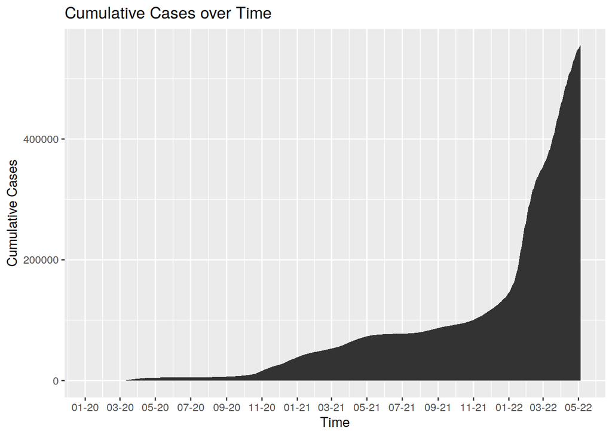

```r
inf_HH %>% select(ref_date, amount_case) %>%
  arrange(ref_date) %>%
  group_by(ref_date) %>%
  summarise(amount_case = sum(amount_case)) %>%
  mutate(cumulative_cases = cumsum(amount_case)) %>%
  ggplot(aes(ref_date, cumulative_cases)) + geom_area() +
  labs(x = "Time", y = "Cumulative Cases", title = "Cumulative Cases over Time") +
  scale_y_continuous(labels = function(x) format(x, scientific = FALSE)) +
  scale_x_date(date_breaks = "2 month", date_labels = "%m-%y")
```

```r
cum_tot_ref_date <- inf_HH %>% select(ref_date, amount_case) %>%
  arrange(ref_date) %>%
  group_by(ref_date) %>%
  summarise(amount_case = sum(amount_case)) %>%
  mutate(cumulative_cases = cumsum(amount_case)) %>%
  ggplot(aes(ref_date, cumulative_cases)) + geom_area() +
  labs(x = "Time", y = "Cumulative Cases", title = "Cumulative Cases over Time") +
  scale_y_continuous(labels = function(x) format(x, scientific = FALSE)) +
  scale_x_date(date_breaks = "2 month", date_labels = "%m-%y")
```

By `rep_date`:

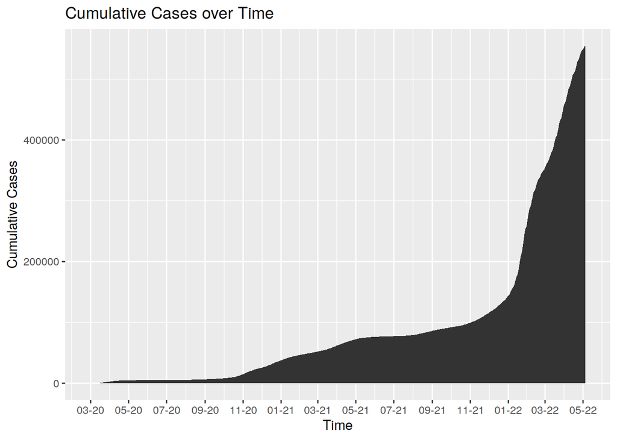

```r
inf_HH %>% select(rep_date, amount_case) %>%
  arrange(rep_date) %>%
  group_by(rep_date) %>%
  summarise(amount_case = sum(amount_case)) %>%
  mutate(cumulative_cases = cumsum(amount_case)) %>%
  ggplot(aes(rep_date, cumulative_cases)) + geom_area() +
  labs(x = "Time", y = "Cumulative Cases", title = "Cumulative Cases over Time") +
  scale_y_continuous(labels = function(x) format(x, scientific = FALSE)) +
  scale_x_date(date_breaks = "2 month", date_labels = "%m-%y")
```

```r
cum_tot_rep_date <- inf_HH %>% select(rep_date, amount_case) %>%
  arrange(rep_date) %>%
  group_by(rep_date) %>%
  summarise(amount_case = sum(amount_case)) %>%
  mutate(cumulative_cases = cumsum(amount_case)) %>%
  ggplot(aes(rep_date, cumulative_cases)) + geom_area() +
  labs(x = "Time", y = "Cumulative Cases", title = "Cumulative Cases over Time") +
  scale_y_continuous(labels = function(x) format(x, scientific = FALSE)) +
  scale_x_date(date_breaks = "2 month", date_labels = "%m-%y")
```

### Cumulative Total of Confirmed Cases by Age Bracket

```r
inf_HH %>%
  group_by(age_group) %>%
  transmute(total_of_confirmed_cases = cumsum(amount_case)) %>%
  slice_tail() %>%
  arrange(desc(total_of_confirmed_cases))
```

```
## # A tibble: 7 × 2
## # Groups:   age_group [7]
##   age_group total_of_confirmed_cases
##   <fct>                        <dbl>
## 1 A35-A59                     196172
## 2 A15-A34                     192849
## 3 A05-A14                      85669
## 4 A60-A79                      43631
## 5 A00-A04                      21368
## 6 A80+                         14890
## 7 unbekannt                      196
```

### Cumulative Total of Confirmed Cases by Age Bracket (Visualised)

by `ref_date`:

```r
AAll_ref_date <- df_age_brackets_ref_date()
```

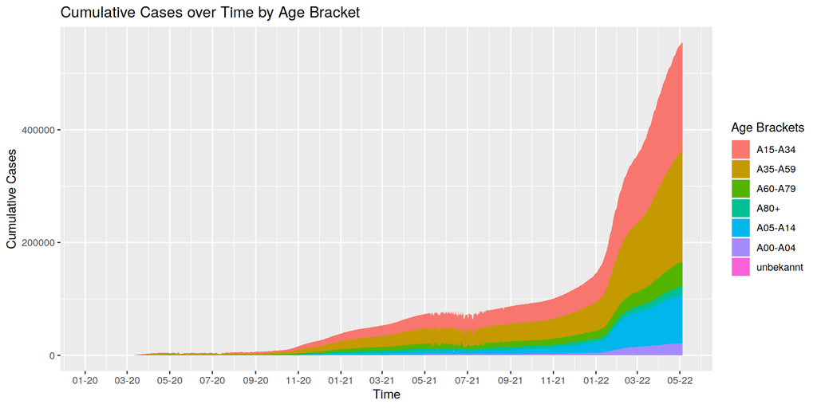

```r
AAll_ref_date %>% ggplot(aes(x = ref_date, y = cum_cases, fill = age_group)) + geom_area() +
  labs(x = "Time", y = "Cumulative Cases", fill = "Age Brackets", title = "Cumulative Cases over Time by Age Bracket") +
  scale_y_continuous(labels = function(x) format(x, scientific = FALSE)) +
  scale_x_date(date_breaks = "2 month", date_labels = "%m-%y")
```

```r
AAllplot_ref_date <- AAll_ref_date %>% ggplot(aes(x = ref_date, y = cum_cases, fill = age_group)) + geom_area(show.legend = FALSE)
```

### Total and by Age Bracket - Side-by-Side

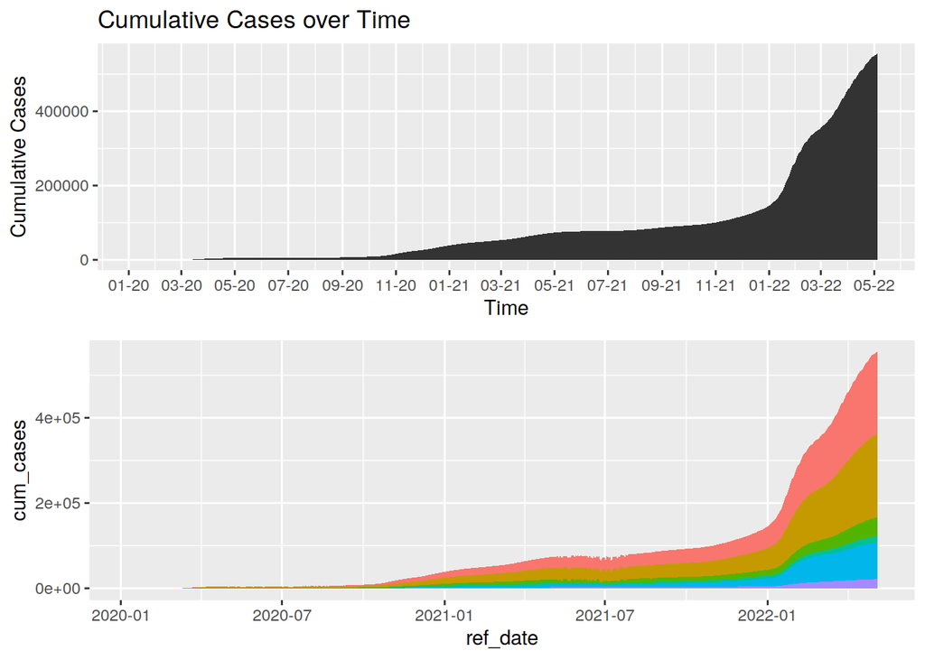

```r
grid.arrange(cum_tot_ref_date, AAllplot_ref_date, nrow = 2)
```

by `rep_date`:

```r
AAll_rep_date <- df_age_brackets_rep_date()
```

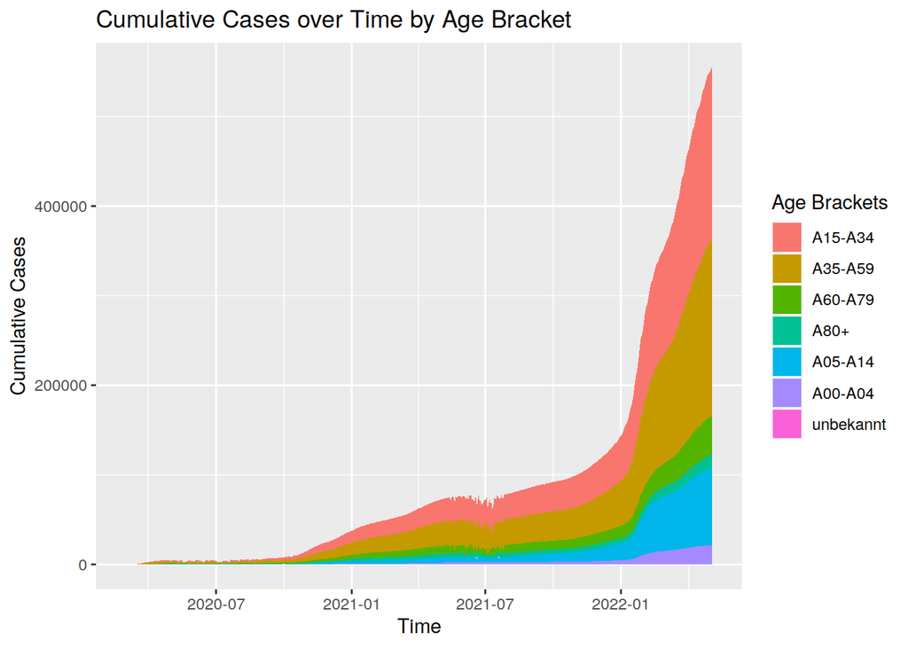

```r
AAll_rep_date %>% ggplot(aes(x = rep_date, y = cum_cases, fill = age_group)) + geom_area() +
  labs(x = "Time", y = "Cumulative Cases", fill = "Age Brackets", title = "Cumulative Cases over Time by Age Bracket") +
  scale_y_continuous(labels = function(x) format(x, scientific = FALSE))
```

```r
AAllplot_rep_date <- AAll_rep_date %>% ggplot(aes(x = rep_date, y = cum_cases, fill = age_group)) + geom_area(show.legend = FALSE)
```

### Total and by Age Bracket - Side-by-Side

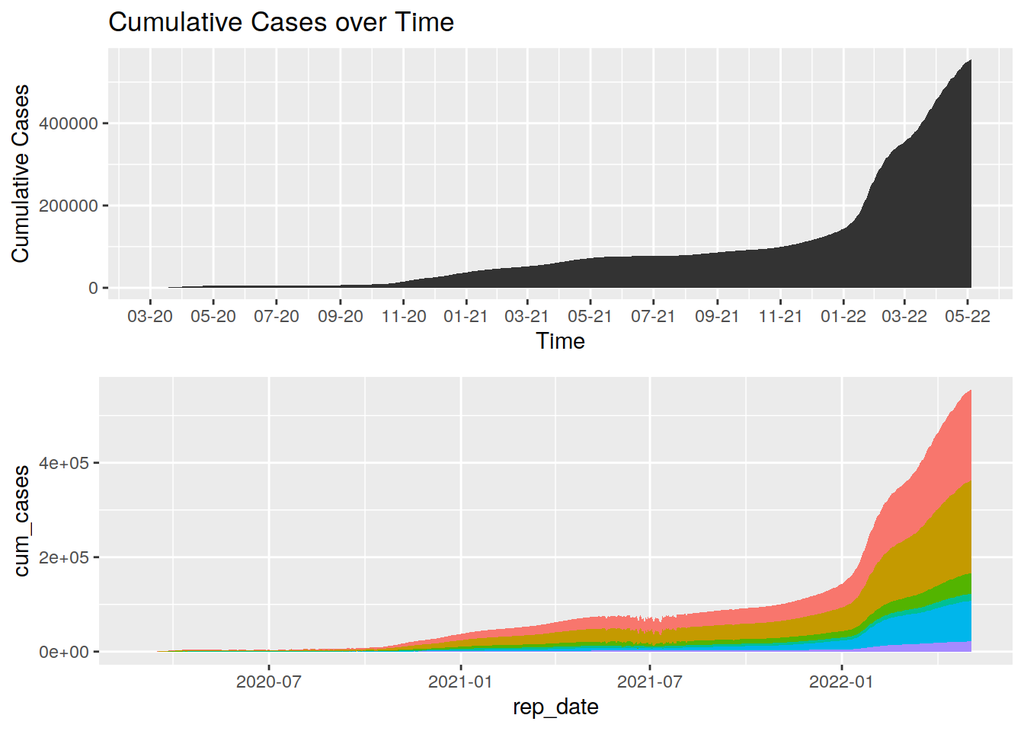

```r
grid.arrange(cum_tot_rep_date, AAllplot_rep_date, nrow = 2)
```

### Total of Confirmed Cases by Age Bracket (Visualised)

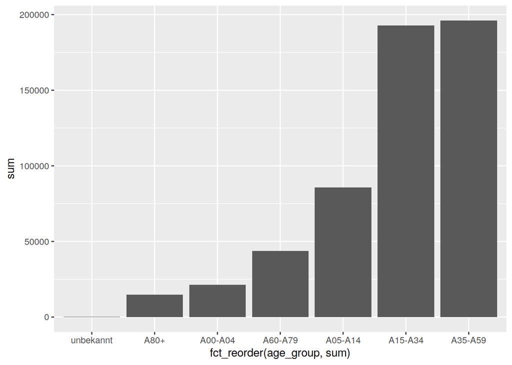

```r
inf_HH %>% select(age_group, amount_case) %>%
  group_by(age_group) %>%
  summarise(sum = sum(amount_case)) %>%
  ggplot(aes(fct_reorder(age_group, sum), sum)) + geom_col()
```

### Total of Confirmed Cases by Sex

```r
inf_HH %>%
  group_by(sex) %>%
  transmute(total_of_confirmed_cases = cumsum(amount_case)) %>%
  slice_tail() %>%
  arrange(desc(total_of_confirmed_cases))
```

```
## # A tibble: 3 × 2
## # Groups:   sex [3]
##   sex       total_of_confirmed_cases
##   <fct>                        <dbl>
## 1 W                           284539
## 2 M                           266954
## 3 unbekannt                     3282
```

### Cumulative Total of Confirmed Cases by Sex (Visualised)

By `ref_date`:

```r
sex_ref_date <- df_sex_ref_date()
```

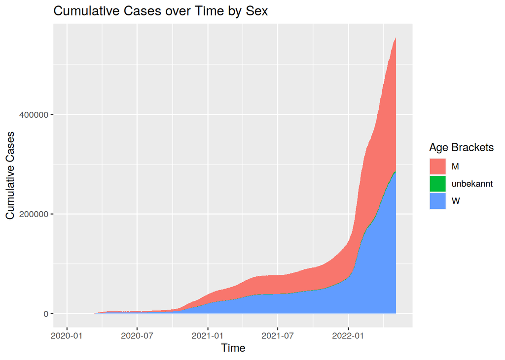

```r
sex_ref_date %>% ggplot(aes(x = ref_date, y = cum_cases, fill = sex)) + geom_area() +
  labs(x = "Time", y = "Cumulative Cases", fill = "Age Brackets", title = "Cumulative Cases over Time by Sex") +
  scale_y_continuous(labels = function(x) format(x, scientific = FALSE))
```

```r
sexplot_ref_date <- sex_ref_date %>% ggplot(aes(x = ref_date, y = cum_cases, fill = sex)) + geom_area(show.legend = FALSE)
```

### Total by Sex Side-by-Side (Visualised)

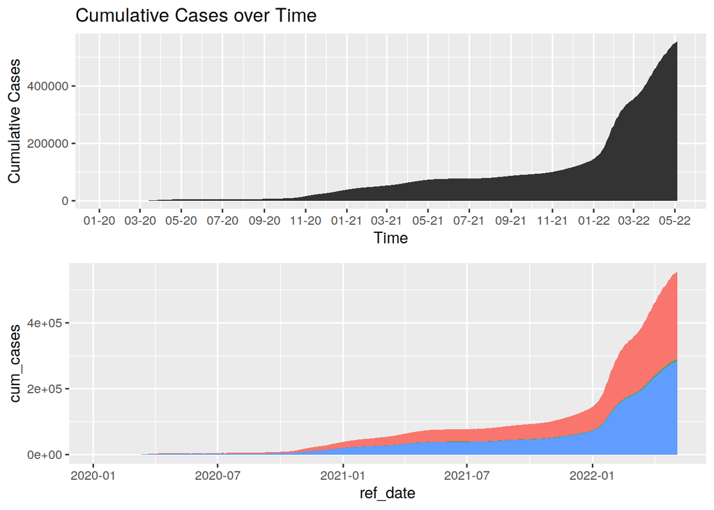

```r
grid.arrange(cum_tot_ref_date, sexplot_ref_date, nrow = 2)
```

By `rep_date`:

```r
sex_rep_date <- df_sex_rep_date()
```

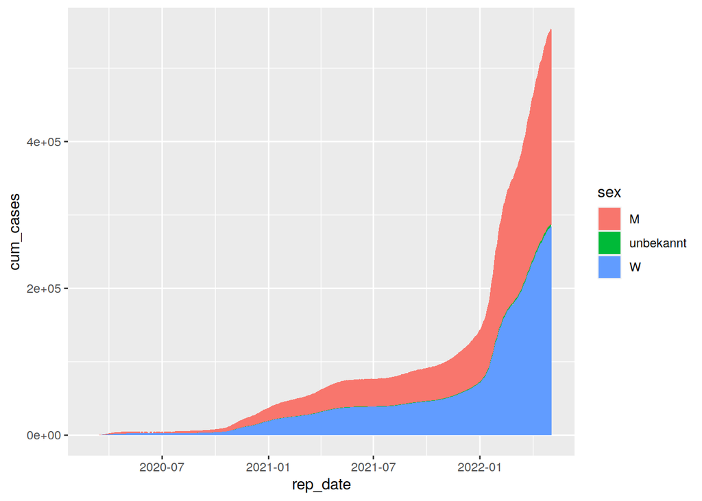

```r
sex_rep_date %>% ggplot(aes(x = rep_date, y = cum_cases, fill = sex)) + geom_area()
```

```r
sexplot_rep_date <- sex_rep_date %>% ggplot(aes(x = rep_date, y = cum_cases, fill = sex)) + geom_area(show.legend = FALSE)
```

### Total by Sex Side-by-Side (Visualised)

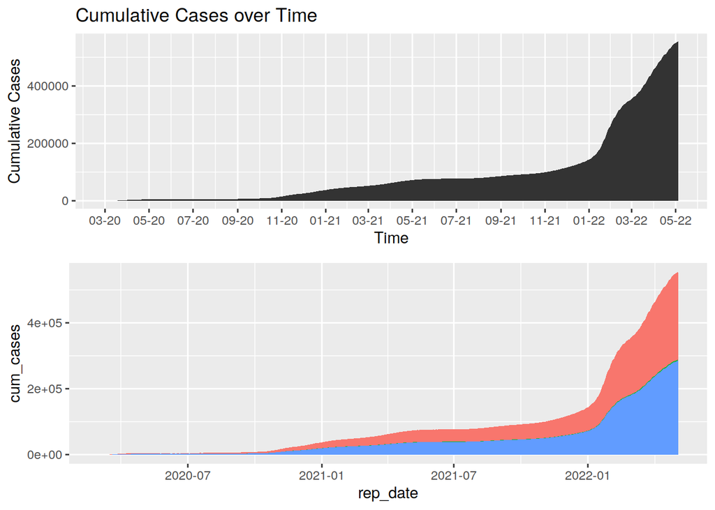

```r
grid.arrange(cum_tot_rep_date, sexplot_rep_date, nrow = 2)
```

## 2.2 Cumulative Deaths

```r
inf_HH %>%
  transmute(total_of_confirmed_deaths = cumsum(amount_death)) %>%
  slice_tail()
```

```
## # A tibble: 1 × 1
##   total_of_confirmed_deaths
##                       <dbl>
## 1                      2562
```

### Cumulative Total of Confirmed Deaths (Visualised)

By `ref_date`:

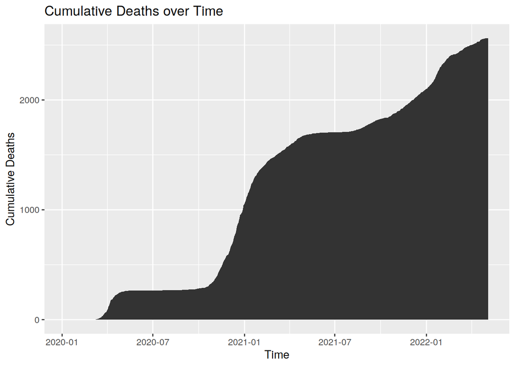

```r
inf_HH %>% select(ref_date, amount_death) %>%
  arrange(ref_date) %>%
  group_by(ref_date) %>%
  summarise(amount_death = sum(amount_death)) %>%
  mutate(cumulative_deaths = cumsum(amount_death)) %>%
  ggplot(aes(ref_date, cumulative_deaths)) + geom_area() +
  labs(x = "Time", y = "Cumulative Deaths", title = "Cumulative Deaths over Time") +
  scale_y_continuous(labels = function(x) format(x, scientific = FALSE))
```

```r
cum_tot_ref_date_deaths <- inf_HH %>% select(ref_date, amount_death) %>%
  arrange(ref_date) %>%
  group_by(ref_date) %>%
  summarise(amount_death = sum(amount_death)) %>%
  mutate(cumulative_deaths = cumsum(amount_death)) %>%
  ggplot(aes(ref_date, cumulative_deaths)) + geom_area() +
  labs(x = "Time", y = "Cumulative Deaths", title = "Cumulative Deaths over Time") +
  scale_y_continuous(labels = function(x) format(x, scientific = FALSE))
```

By `rep_date`:

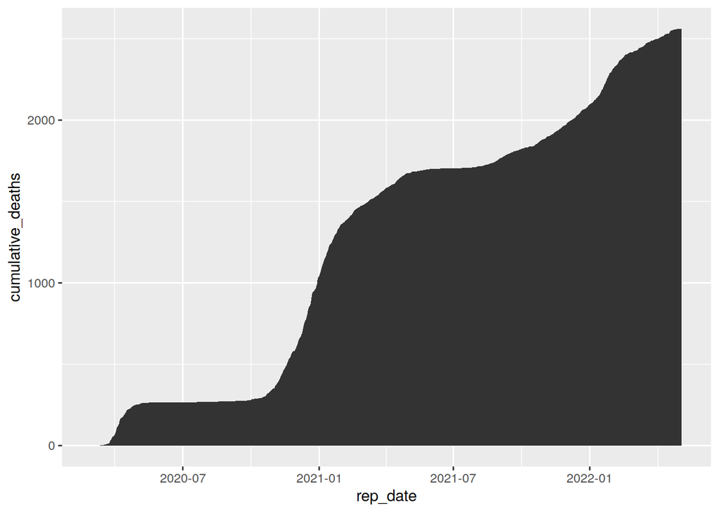

```r
inf_HH %>% select(rep_date, amount_death) %>%
  arrange(rep_date) %>%
  group_by(rep_date) %>%
  summarise(amount_death = sum(amount_death)) %>%
  mutate(cumulative_deaths = cumsum(amount_death)) %>%
  ggplot(aes(rep_date, cumulative_deaths)) + geom_area()
```

```r
cum_tot_rep_date_deaths <- inf_HH %>% select(rep_date, amount_death) %>%
  arrange(rep_date) %>%
  group_by(rep_date) %>%
  summarise(amount_death = sum(amount_death)) %>%
  mutate(cumulative_deaths = cumsum(amount_death)) %>%
  ggplot(aes(rep_date, cumulative_deaths)) + geom_area()
```

#### Sorted By Age Group Descending

```r
inf_HH %>%
  group_by(age_group) %>%
  transmute(total_of_confirmed_deaths = cumsum(amount_death)) %>%
  slice_tail() %>%
  arrange(desc(total_of_confirmed_deaths))
```

```
## # A tibble: 7 × 2
## # Groups:   age_group [7]
##   age_group total_of_confirmed_deaths
##   <fct>                         <dbl>
## 1 A80+                           1568
## 2 A60-A79                         805
## 3 A35-A59                         169
## 4 A15-A34                          17
## 5 A00-A04                           2
## 6 A05-A14                           1
## 7 unbekannt                         0
```

### Cumulative Total of Confirmed Deaths by Age Bracket

By `ref_date`:

```r
AAll_ref_date_deaths <- df_age_brackets_ref_date_deaths()
```

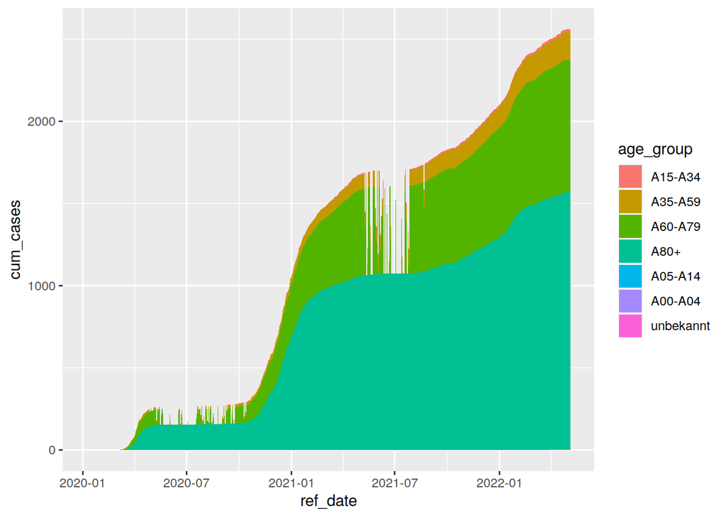

```r
AAll_ref_date_deaths %>% ggplot(aes(x = ref_date, y = cum_cases, fill = age_group)) + geom_area()
```

```r
AAllplot_ref_date_deaths <- AAll_ref_date_deaths %>% ggplot(aes(x = ref_date, y = cum_cases, fill = age_group)) + geom_area(show.legend = FALSE)
```

### Total and by Age Bracket - Side-by-Side

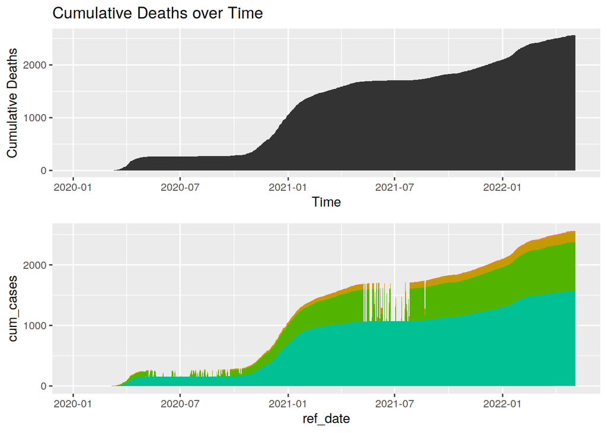

```r
grid.arrange(cum_tot_ref_date_deaths, AAllplot_ref_date_deaths, nrow = 2)
```

By `rep_date`:

```r
AAll_rep_date_deaths <- df_age_brackets_rep_date_deaths()
```

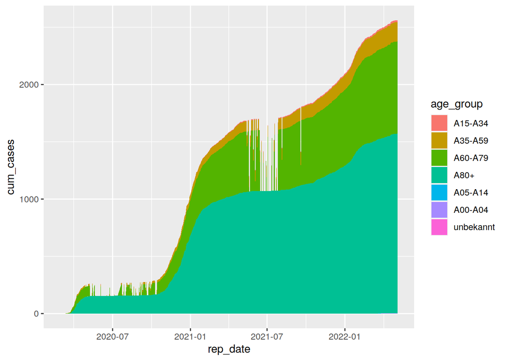

```r
AAll_rep_date_deaths %>% ggplot(aes(x = rep_date, y = cum_cases, fill = age_group)) + geom_area()
```

```r
AAllplot_rep_date_deaths <- AAll_rep_date_deaths %>% ggplot(aes(x = rep_date, y = cum_cases, fill = age_group)) + geom_area(show.legend = FALSE)
```

### Total and by Age Bracket - Side-by-Side

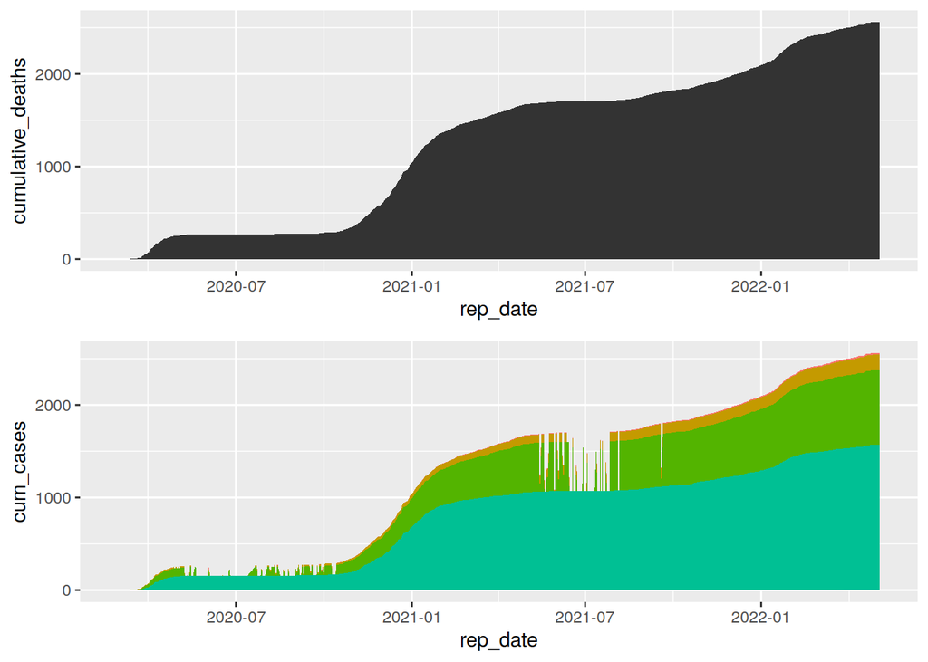

```r
grid.arrange(cum_tot_rep_date_deaths, AAllplot_rep_date_deaths, nrow = 2)
```

### Total of Confirmed Deaths by Age Bracket (Visualised)

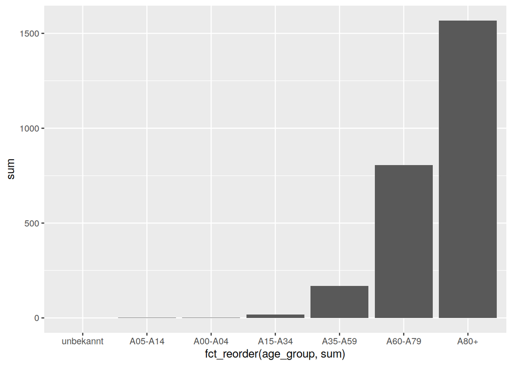

```r
inf_HH %>% select(age_group, amount_death) %>%
  group_by(age_group) %>%
  summarise(sum = sum(amount_death)) %>%
  ggplot(aes(fct_reorder(age_group, sum), sum)) + geom_col()
```

#### Sorted by Sex

```r
inf_HH %>%
  group_by(sex) %>%
  transmute(total_of_confirmed_deaths = cumsum(amount_death)) %>%
  slice_tail() %>%
  arrange(desc(total_of_confirmed_deaths))
```

```
## # A tibble: 3 × 2
## # Groups:   sex [3]
##   sex       total_of_confirmed_deaths
##   <fct>                         <dbl>
## 1 M                              1406
## 2 W                              1156
## 3 unbekannt                         0
```

### Cumulative Total of Confirmed Deaths by Sex (Visualised)

By `ref_date`:

```r
sex_ref_date_deaths <- df_sex_ref_date_deaths()
```

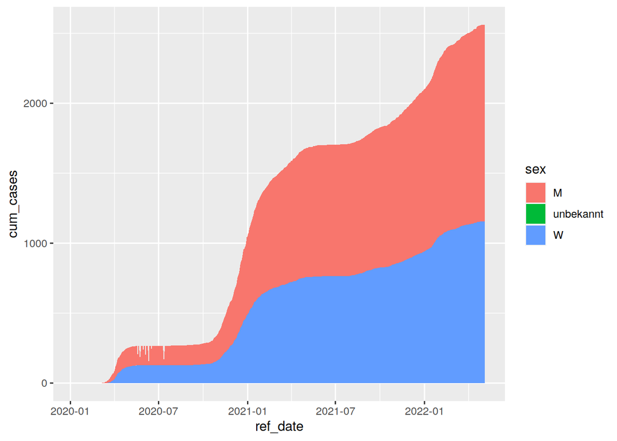

```r
sex_ref_date_deaths %>% ggplot(aes(x = ref_date, y = cum_cases, fill = sex)) + geom_area()
```

```r
sexplot_ref_date_deaths <- sex_ref_date_deaths %>% ggplot(aes(x = ref_date, y = cum_cases, fill = sex)) + geom_area(show.legend = FALSE)
```

### Total by Sex Side-by-Side (Visualised)

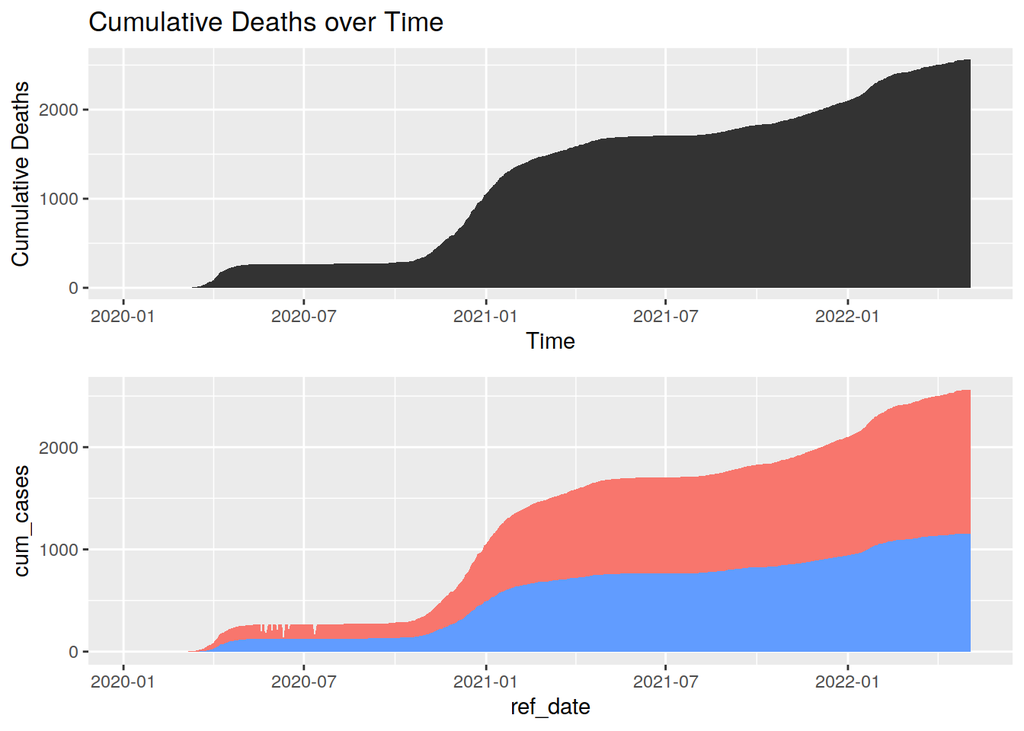

```r
grid.arrange(cum_tot_ref_date_deaths, sexplot_ref_date_deaths, nrow = 2)
```

By `rep_date`:

```r
sex_rep_date_deaths <- df_sex_rep_date_deaths()
```

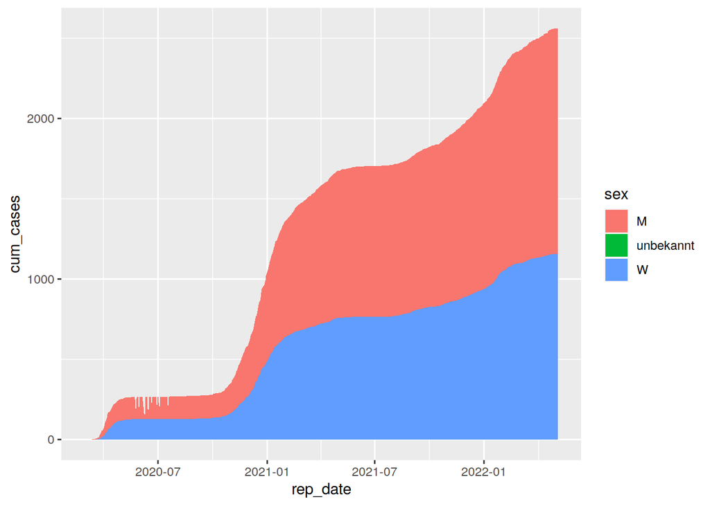

```r
sex_rep_date_deaths %>% ggplot(aes(x = rep_date, y = cum_cases, fill = sex)) + geom_area()
```

```r
sexplot_rep_date_deaths <- sex_rep_date_deaths %>% ggplot(aes(x = rep_date, y = cum_cases, fill = sex)) + geom_area(show.legend = FALSE)
```

### Total by Sex Side-by-Side (Visualised)

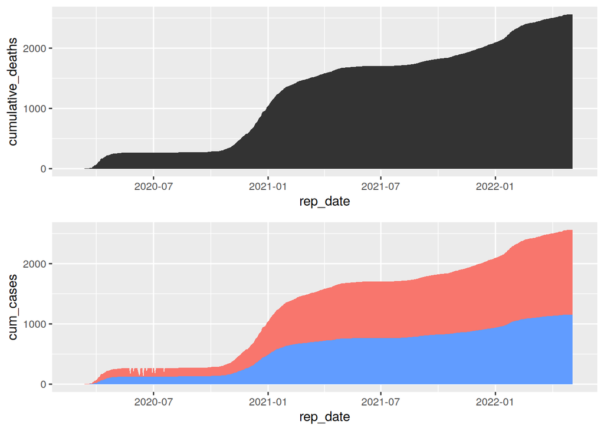

```r
grid.arrange(cum_tot_rep_date_deaths, sexplot_rep_date_deaths, nrow = 2)
```

## 2.2 Cumulative Recoveries

```r
inf_HH %>%
  transmute(total_of_confirmed_recoveries = cumsum(amount_recovery)) %>%
  slice_tail()
```

```
## # A tibble: 1 × 1
##   total_of_confirmed_recoveries
##                           <dbl>
## 1                        486925
```

### Cumulative Total of Confirmed Recoveries (Visualised)

By `ref_date`

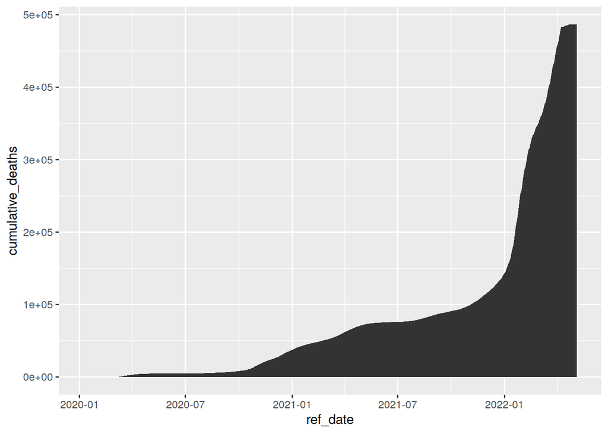

```r
inf_HH %>% select(ref_date, amount_recovery) %>%
  arrange(ref_date) %>%
  group_by(ref_date) %>%
  summarise(amount_recovery = sum(amount_recovery)) %>%
  mutate(cumulative_deaths = cumsum(amount_recovery)) %>%
  ggplot(aes(ref_date, cumulative_deaths)) + geom_area()
```

```r
cum_tot_ref_date_recoveries <- inf_HH %>% select(ref_date, amount_recovery) %>%
  arrange(ref_date) %>%
  group_by(ref_date) %>%
  summarise(amount_recovery = sum(amount_recovery)) %>%
  mutate(cumulative_deaths = cumsum(amount_recovery)) %>%
  ggplot(aes(ref_date, cumulative_deaths)) + geom_area()
```

By `rep_date`

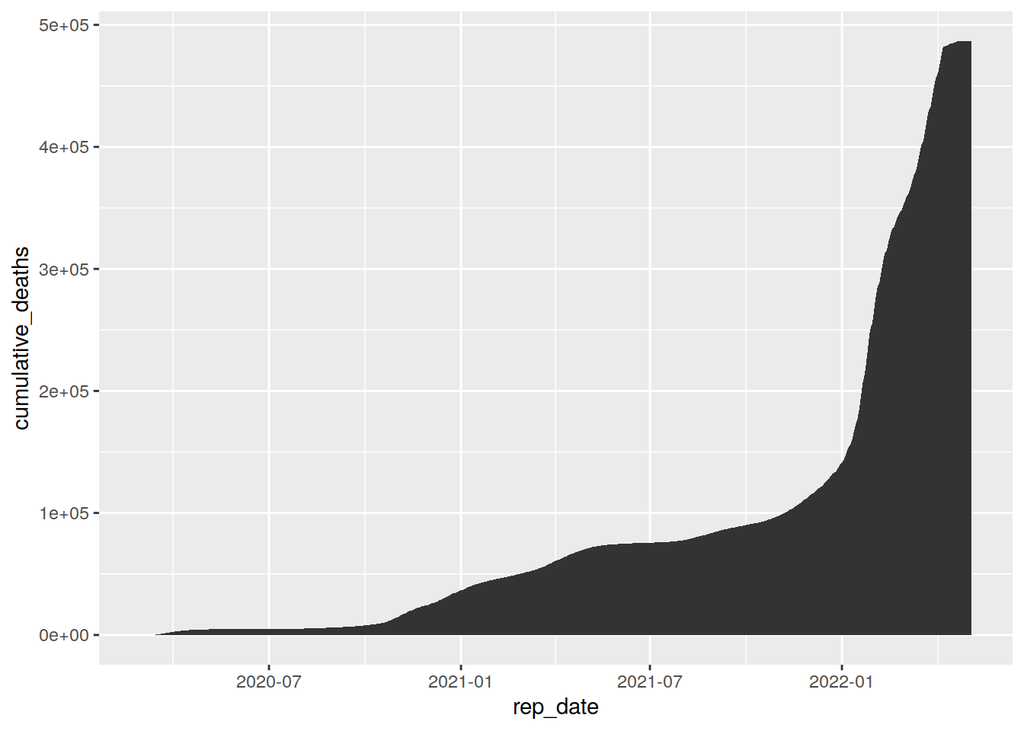

```r
inf_HH %>% select(rep_date, amount_recovery) %>%
  arrange(rep_date) %>%
  group_by(rep_date) %>%
  summarise(amount_recovery = sum(amount_recovery)) %>%
  mutate(cumulative_deaths = cumsum(amount_recovery)) %>%
  ggplot(aes(rep_date, cumulative_deaths)) + geom_area()
```

```r
cum_tot_rep_date_recoveries <- inf_HH %>% select(rep_date, amount_recovery) %>%
  arrange(rep_date) %>%
  group_by(rep_date) %>%
  summarise(amount_recovery = sum(amount_recovery)) %>%
  mutate(cumulative_deaths = cumsum(amount_recovery)) %>%
  ggplot(aes(rep_date, cumulative_deaths)) + geom_area()
```

#### Sorted by Age Bracket Descending

```r
inf_HH %>%
  group_by(age_group) %>%
  transmute(total_of_confirmed_recoveries = cumsum(amount_recovery)) %>%
  slice_tail() %>%
  arrange(desc(total_of_confirmed_recoveries))
```

```
## # A tibble: 7 × 2
## # Groups:   age_group [7]
##   age_group total_of_confirmed_recoveries
##   <fct>                             <dbl>
## 1 A35-A59                          171394
## 2 A15-A34                          170498
## 3 A05-A14                           77294
## 4 A60-A79                           36652
## 5 A00-A04                           19304
## 6 A80+                              11599
## 7 unbekannt                           184
```

By `ref_date`:

```r
AAll_ref_date_recoveries <- df_age_brackets_ref_date_recoveries()
```

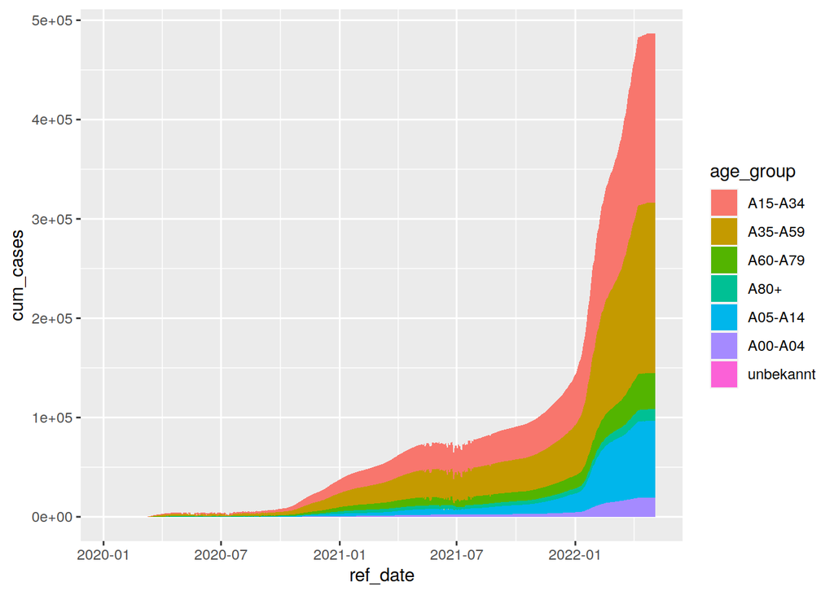

```r
AAll_ref_date_recoveries %>% ggplot(aes(x = ref_date, y = cum_cases, fill = age_group)) + geom_area()
```

```r
AAllplot_ref_date_recoveries <- AAll_ref_date_recoveries %>% ggplot(aes(x = ref_date, y = cum_cases, fill = age_group)) + geom_area(show.legend = FALSE)
```

### Total and by Age Bracket - Side-by-Side

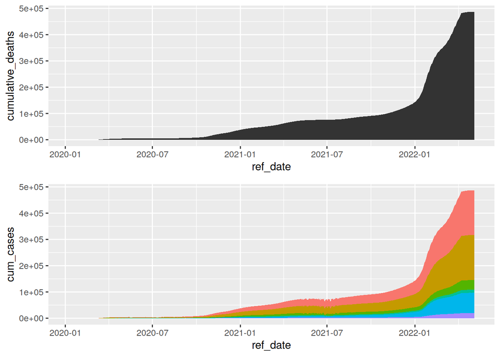

```r
grid.arrange(cum_tot_ref_date_recoveries, AAllplot_ref_date_recoveries, nrow = 2)
```

```r
AAll_ref_date_recoveries <- df_age_brackets_ref_date_recoveries()
```

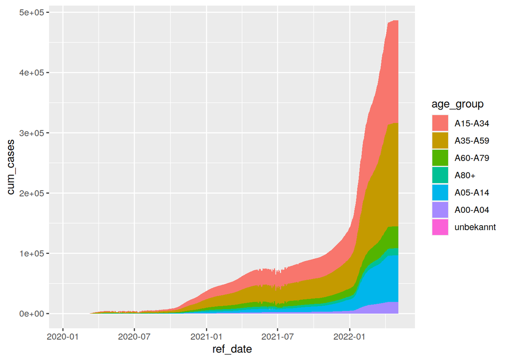

```r
AAll_ref_date_recoveries %>% ggplot(aes(x = ref_date, y = cum_cases, fill = age_group)) + geom_area()
```

```r
AAllplot_rep_date_recoveries <- AAll_ref_date_recoveries %>% ggplot(aes(x = ref_date, y = cum_cases, fill = age_group)) + geom_area(show.legend = FALSE)
```

### Total and by Age Bracket - Side-by-Side

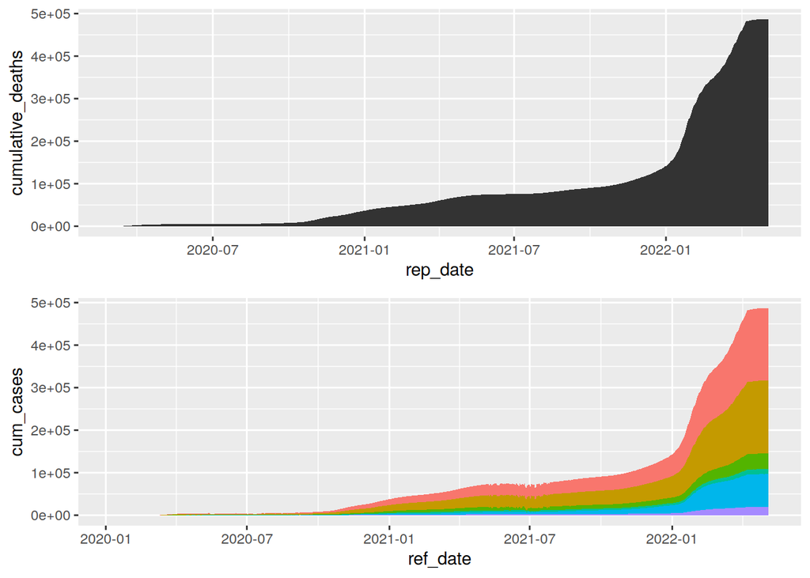

```r
grid.arrange(cum_tot_rep_date_recoveries, AAllplot_rep_date_recoveries, nrow = 2)
```

### Total of Confirmed Recoveries by Age Bracket (Visualised)

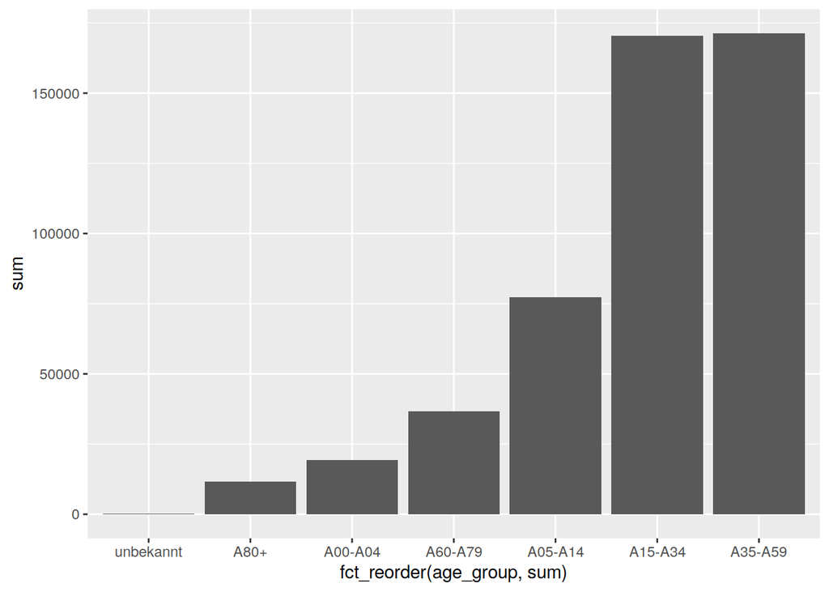

```r
inf_HH %>% select(age_group, amount_recovery) %>%
  group_by(age_group) %>%
  summarise(sum = sum(amount_recovery)) %>%
  ggplot(aes(fct_reorder(age_group, sum), sum)) + geom_col()
```

#### Sorted by Sex

```r
inf_HH %>%
  group_by(sex) %>%
  transmute(total_of_confirmed_recoveries = cumsum(amount_recovery)) %>%
  slice_tail() %>%
  arrange(desc(total_of_confirmed_recoveries))
```

```
## # A tibble: 3 × 2
## # Groups:   sex [3]
##   sex       total_of_confirmed_recoveries
##   <fct>                             <dbl>
## 1 W                                249537
## 2 M                                234649
## 3 unbekannt                          2739
```

### Cumulative Total of Confirmed Recoveries by Sex (Visualised)

By `ref_date`:

```r
sex_ref_date_recoveries <- df_sex_ref_date_recoveries()
```

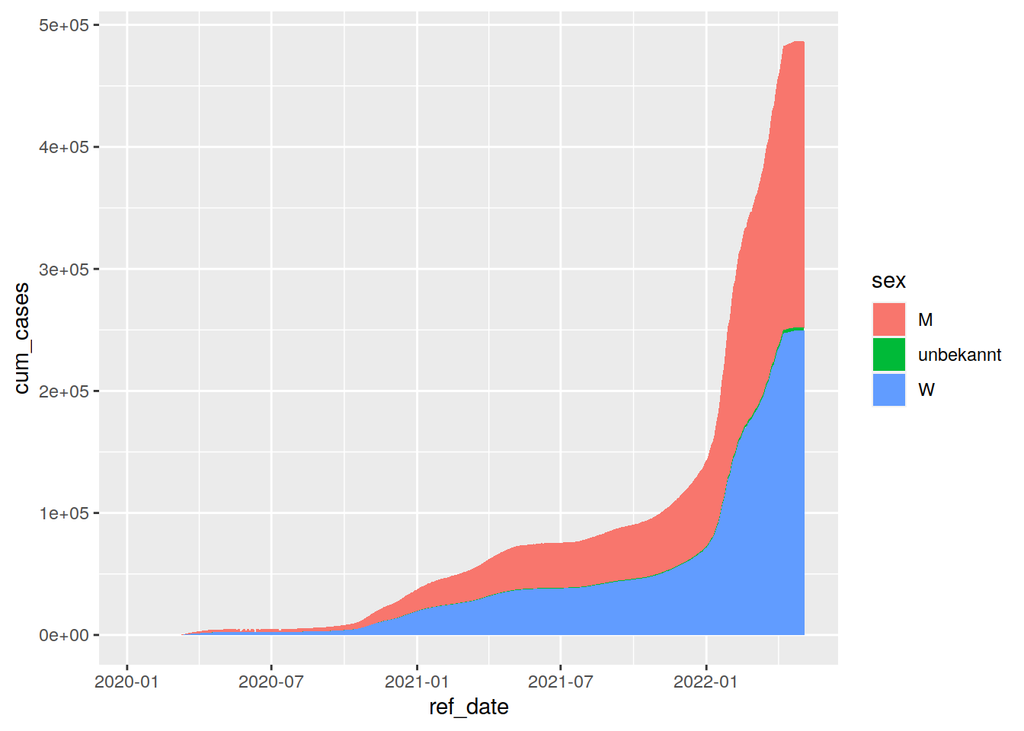

```r
sex_ref_date_recoveries %>% ggplot(aes(x = ref_date, y = cum_cases, fill = sex)) + geom_area()
```

```r
sexplot_ref_date_recoveries <- sex_ref_date_recoveries %>% ggplot(aes(x = ref_date, y = cum_cases, fill = sex)) + geom_area(show.legend = FALSE)
```